# FIA + Climate Analysis Notebook

Libraries:

Read in the data:

```
'data.frame':   6922 obs. of  42 variables:
 $ X                      : int  1 2 3 4 5 6 7 8 9 10 ...
 $ PLT_CN                 : num  3.64e+12 3.64e+12 3.64e+12 3.64e+12 3.64e+12 ...
 $ LAT                    : num  37.3 37.2 37 37.3 37 ...
 $ LON                    : num  -107 -107 -107 -107 -107 ...
 $ ELEV                   : int  8050 8090 7160 9990 8110 6800 6100 7860 9200 11080 ...
 $ SPCD_202               : int  9 8 9 0 0 0 0 5 33 0 ...
 $ SPCD_746               : int  17 0 0 0 0 0 0 0 16 5 ...
 $ SPCD_122               : int  0 4 16 0 11 0 8 11 0 0 ...
 $ SPCD_814               : int  0 14 19 0 0 1 0 0 0 0 ...
 $ SPCD_19                : int  0 0 0 17 0 0 0 0 0 0 ...
 $ SPCD_93                : int  0 0 0 1 0 0 0 0 0 26 ...
 $ SPCD_65                : int  0 0 0 0 0 2 0 0 0 0 ...
 $ SPCD_106               : int  0 0 0 0 0 5 0 0 0 0 ...
 $ SPCD_108               : int  0 0 0 0 0 0 0 5 7 0 ...
```

[output cut: 23 more lines]

[output not shown]

[output not shown]

Recall:

1. 746 is quaking aspen,
2. 93 Engelmann spruce,
3. 108 lodgepole pine,
4. 814 Gambel oak,
5. 19 subalpine fir

Remove some of the identifier codes, turn species code into one-hot columns and re-scale the continuous variables:

|  | LAT | LON | ELEV | SPCD_aspen | SPCD_oak | SPCD_fir | SPCD_spruce | SPCD_pine | FIELD_MOIST_SOIL_WT | BULK_DENSITY | C_TOTAL_PCT | N_TOTAL_PCT | FORFLTHK | LTRLRTHK | DPTHSBSL | AVGT | JANT | JULT | PPT | VARS | VARW | VARP | VARA | DIFS | DIFW | PPTS | PPTW |
| --- | --- | --- | --- | --- | --- | --- | --- | --- | --- | --- | --- | --- | --- | --- | --- | --- | --- | --- | --- | --- | --- | --- | --- | --- | --- | --- | --- |
| 1 | 37.29803 | -107.3133 | -0.3705168 | 1 | 0 | 0 | 0 | 0 | -0.005923661 | 2.203016888 | -1.5275648 | -1.4760403 | 0.5974288 | 1.4273758 | 0.5552191 | 0.5657900 | 0.6119749 | 0.15299618 | -0.8030406 | -1.235772 | -0.9937666 | -0.6773857 | -0.6258162 | -1.219842 | -0.1142249 | -0.2345339 | 0.471206369 |
| 2 | 37.20763 | -107.4224 | -0.3078649 | 0 | 1 | 0 | 0 | 0 | -0.359545936 | -0.141229627 | 0.4104437 | 0.3870496 | -0.2679373 | 0.1792698 | -0.8651170 | 0.7763803 | 0.7905080 | 0.37649957 | -1.0742471 | -1.177111 | -0.9382627 | -0.8103992 | -0.5364359 | -1.350550 | -0.2390835 | -0.3461005 | 0.406229261 |
| 3 | 37.02951 | -106.9084 | -0.8717317 | 0 | 1 | 0 | 0 | 0 | -0.681855892 | -0.006486738 | -0.6249303 | -0.5524783 | 0.1419730 | 1.2833636 | -0.1955300 | 0.5426025 | 0.6824807 | -0.04923051 | -1.0564225 | -1.514419 | -0.9967508 | -0.5677147 | -0.9420145 | -1.420609 | 0.0432432 | 0.1537592 | 0.054525084 |
| 4 | 37.32485 | -106.8509 | 0.8825207 | 0 | 0 | 1 | 1 | 0 | -0.279663894 | -0.517017751 | 0.7655727 | 1.3554388 | 0.2102914 | 0.1792698 | -0.2969826 | 0.1690097 | 0.3361085 | -0.37669465 | -0.4966044 | -1.499804 | -1.0896844 | -0.3229999 | -0.9919784 | -1.018507 | 0.2619304 | 0.2522470 | 0.246693065 |
| 5 | 36.99328 | -106.8636 | -0.3078649 | 0 | 0 | 0 | 0 | 0 | -0.681855892 | -0.006486738 | -0.6249303 | -0.5524783 | 0.1419730 | 1.2833636 | -0.1955300 | 0.5607949 | 0.7100640 | -0.05112323 | -1.1001881 | -1.535563 | -0.9902957 | -0.5527727 | -0.9723612 | -1.456441 | 0.0524402 | 0.1980141 | -0.004870342 |
| 6 | 37.02996 | -107.1870 | -1.1223392 | 0 | 1 | 0 | 0 | 0 | -0.339459517 | 1.221585123 | -0.9095506 | -0.8266608 | 0.9162479 | 1.5233840 | 0.4943475 | 0.7454476 | 0.8156949 | 0.23363995 | -1.2308302 | -1.369153 | -0.9450830 | -0.7885099 | -0.7342955 | -1.493141 | -0.1581325 | -0.1379723 | 0.194110900 |

Import and re-scale the prediction grid data by the mean and standard deviation of the original data:

|  | LON | LAT | ELEV | FIELD_MOIST_SOIL_WT | BULK_DENSITY | C_TOTAL_PCT | N_TOTAL_PCT | FORFLTHK | LTRLRTHK | DPTHSBSL | AVGT | JANT | JULT | PPT | VARS | VARW | VARP | VARA | DIFS | DIFW | PPTS | PPTW |
| --- | --- | --- | --- | --- | --- | --- | --- | --- | --- | --- | --- | --- | --- | --- | --- | --- | --- | --- | --- | --- | --- | --- |
| 1 | -109.0587 | 36.99328 | -2.294833 | -0.7001586 | 0.4610338 | -0.2955869 | -0.9494749 | -0.7917115 | -0.6848036 | -0.276692 | 2.553797 | 2.165504 | 2.520587 | -3.603619 | -0.1722721 | -0.4734933 | 1.324535e-05 | 0.6505907 | -2.519074 | -1.231093 | -1.284415 | -0.6132096 |
| 2 | -109.0487 | 36.99328 | -2.294833 | -0.7001586 | 0.4610338 | -0.2955869 | -0.9494749 | -0.7917115 | -0.6848036 | -0.276692 | 2.548097 | 2.161954 | 2.512882 | -3.589881 | -0.1756840 | -0.4753612 | 1.327027e-05 | 0.6446994 | -2.508381 | -1.227548 | -1.280220 | -0.6073133 |
| 3 | -109.0387 | 36.99328 | -2.294833 | -0.7001586 | 0.4610338 | -0.2955869 | -0.9494749 | -0.7917115 | -0.6848036 | -0.276692 | 2.542352 | 2.158363 | 2.505125 | -3.576135 | -0.1791362 | -0.4772316 | 1.329511e-05 | 0.6387908 | -2.497725 | -1.223981 | -1.276035 | -0.6013846 |
| 4 | -109.0287 | 36.99328 | -2.294833 | -0.7001586 | 0.4610338 | -0.2955869 | -0.9494749 | -0.7917115 | -0.6848036 | -0.276692 | 2.536561 | 2.154730 | 2.497318 | -3.562380 | -0.1826290 | -0.4791043 | 1.331986e-05 | 0.6328649 | -2.487108 | -1.220392 | -1.271861 | -0.5954241 |
| 5 | -109.0187 | 36.99328 | -2.294833 | -0.7001586 | 0.4610338 | -0.2955869 | -0.9494749 | -0.7917115 | -0.6848036 | -0.276692 | 2.530723 | 2.151054 | 2.489458 | -3.548617 | -0.1861629 | -0.4809797 | 1.334452e-05 | 0.6269215 | -2.476531 | -1.216781 | -1.267695 | -0.5894318 |
| 6 | -109.0087 | 36.99328 | -2.294833 | -0.7001586 | 0.4610338 | -0.2955869 | -0.9494749 | -0.7917115 | -0.6848036 | -0.276692 | 2.524838 | 2.147335 | 2.481546 | -3.534846 | -0.1897382 | -0.4828576 | 1.336909e-05 | 0.6209604 | -2.465996 | -1.213147 | -1.263539 | -0.5834080 |

Create data matrices for boosting:

Helper functions to determine the optimum depth and learning rate of XGBoosting for a fixed number of rounds using the precision-recall AUC metric.

## Optimize hyper-parameters for the tree species

Get best hyper parameters for each of the tree species using a (non-exhaustive) grid search:

- Aspen: depth = 4, eta = 0.3
- Spruce : depth = 3, eta = 0.3
- Pine: depth = 3, eta = 0.5
- Oak: depth = 3, eath = 0.3
- Fir: depth = 3, eta = 0.3

Generally, the tendency is to over-fit the data.

## Examining Aspen Predictions

Model fitting and prediction accuracy:

```
[14:44:54] WARNING: amalgamation/../src/learner.cc:1061: Starting in XGBoost 1.3.0, the default evaluation metric used with the objective 'binary:logistic' was changed from 'error' to 'logloss'. Explicitly set eval_metric if you'd like to restore the old behavior.
[1] 0.7962428
[1] 0.8122066
[1] 0.8397727
[1] 0.8546268
```

Make a spatial/map plot:

[output not shown]

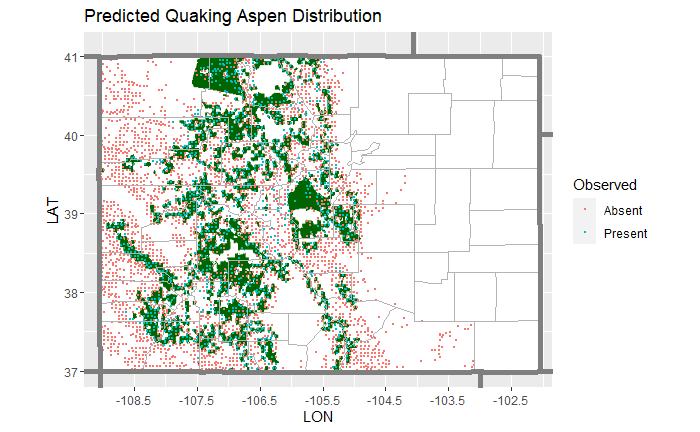

Get a list of variable importance:

| Feature | Gain | Cover | Frequency |
| --- | --- | --- | --- |
| ELEV | 0.7699651735 | 0.5671791531 | 0.292857143 |
| VARA | 0.0429480346 | 0.0402710812 | 0.050000000 |
| JANT | 0.0376934746 | 0.0522541510 | 0.050000000 |
| PPTS | 0.0266832966 | 0.0225372919 | 0.050000000 |
| PPT | 0.0217830313 | 0.0534859065 | 0.078571429 |
| AVGT | 0.0175280854 | 0.0334139674 | 0.107142857 |
| JULT | 0.0162082657 | 0.0633953690 | 0.064285714 |
| VARS | 0.0138212283 | 0.0148223187 | 0.021428571 |
| VARW | 0.0109446343 | 0.0237749024 | 0.064285714 |
| PPTW | 0.0090233650 | 0.0281581382 | 0.014285714 |

[output cut: 9 more lines]

## Examining Spruce Predictions:

Fit a model and make predictions:

Model fitting and prediction accuracy:

```
[14:45:00] WARNING: amalgamation/../src/learner.cc:1061: Starting in XGBoost 1.3.0, the default evaluation metric used with the objective 'binary:logistic' was changed from 'error' to 'logloss'. Explicitly set eval_metric if you'd like to restore the old behavior.
[1] 0.8533237
[1] 0.8699892
[1] 0.8853755
[1] 0.8998331
```

Plot predictions:

[output not shown]

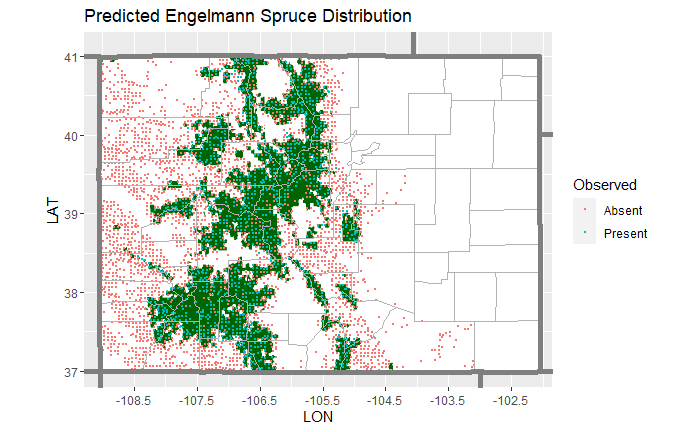

Get a list of variable importance:

| Feature | Gain | Cover | Frequency |
| --- | --- | --- | --- |
| ELEV | 0.9197662013 | 0.709329862 | 0.46376812 |
| VARA | 0.0175559046 | 0.049239188 | 0.10144928 |
| JANT | 0.0159623529 | 0.069256978 | 0.10144928 |
| VARW | 0.0155723821 | 0.051537371 | 0.13043478 |
| JULT | 0.0154556004 | 0.056419096 | 0.08695652 |
| DIFW | 0.0087671199 | 0.025903338 | 0.04347826 |
| VARP | 0.0039117364 | 0.016143029 | 0.02898551 |
| DPTHSBSL | 0.0019746476 | 0.014507096 | 0.01449275 |
| DIFS | 0.0006406648 | 0.004537084 | 0.01449275 |
| PPTW | 0.0003933899 | 0.003126957 | 0.01449275 |

## Examining Pine

Model fitting and prediction accuracy:

```
[14:45:04] WARNING: amalgamation/../src/learner.cc:1061: Starting in XGBoost 1.3.0, the default evaluation metric used with the objective 'binary:logistic' was changed from 'error' to 'logloss'. Explicitly set eval_metric if you'd like to restore the old behavior.
[1] 0.8742775
[1] 0.87974
[1] 0.9200368
[1] 0.9241458
```

Plot predictions:

[output not shown]

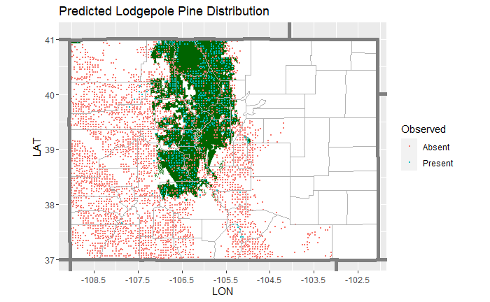

Get a list of variable importance:

| Feature | Gain | Cover | Frequency |
| --- | --- | --- | --- |
| DIFS | 0.4124622782 | 0.2400214029 | 0.11940299 |
| DIFW | 0.2004049915 | 0.1038007878 | 0.07462687 |
| ELEV | 0.1979519827 | 0.2390848881 | 0.20895522 |
| JANT | 0.0354532343 | 0.0429159571 | 0.04477612 |
| VARW | 0.0307931438 | 0.0434286803 | 0.08955224 |
| JULT | 0.0284400547 | 0.0878904221 | 0.05970149 |
| PPTS | 0.0259956700 | 0.1070976215 | 0.10447761 |
| PPTW | 0.0131615294 | 0.0097759367 | 0.04477612 |
| VARA | 0.0093889873 | 0.0319598997 | 0.02985075 |
| PPT | 0.0073493692 | 0.0082935686 | 0.02985075 |

[output cut: 9 more lines]

## Examining Oak

Model fitting and prediction accuracy:

```
[14:45:09] WARNING: amalgamation/../src/learner.cc:1061: Starting in XGBoost 1.3.0, the default evaluation metric used with the objective 'binary:logistic' was changed from 'error' to 'logloss'. Explicitly set eval_metric if you'd like to restore the old behavior.
[1] 0.8547688
[1] 0.8690863
[1] 0.9032258
[1] 0.912429
```

Plot predictions:

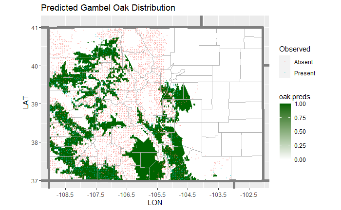

Get a list of variable importance:

| Feature | Gain | Cover | Frequency |
| --- | --- | --- | --- |
| ELEV | 0.6562054515 | 0.5128329938 | 0.31884058 |
| DIFS | 0.0849463127 | 0.0751920276 | 0.08695652 |
| VARS | 0.0771897865 | 0.1168058011 | 0.08695652 |
| PPTW | 0.0503847239 | 0.0651978389 | 0.05797101 |
| VARA | 0.0245881206 | 0.0451745989 | 0.05797101 |
| DIFW | 0.0201333153 | 0.0287198447 | 0.05797101 |
| JULT | 0.0185995569 | 0.0371958513 | 0.07246377 |
| PPT | 0.0182096313 | 0.0514778920 | 0.05797101 |
| AVGT | 0.0132950173 | 0.0154474164 | 0.02898551 |
| VARW | 0.0127622846 | 0.0282235518 | 0.04347826 |

[output cut: 5 more lines]

## Examining FIR

Model fitting and prediction accuracy:

```
[14:45:15] WARNING: amalgamation/../src/learner.cc:1061: Starting in XGBoost 1.3.0, the default evaluation metric used with the objective 'binary:logistic' was changed from 'error' to 'logloss'. Explicitly set eval_metric if you'd like to restore the old behavior.
[1] 0.8352601
[1] 0.8279162
[1] 0.8850806
[1] 0.8824763
```

Plot predictions:

[output not shown]

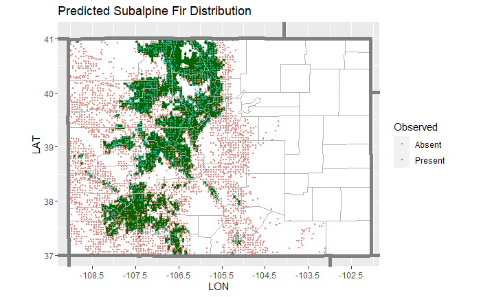

Get a list of variable importance:

| Feature | Gain | Cover | Frequency |
| --- | --- | --- | --- |
| ELEV | 0.5997632586 | 0.4713372988 | 0.34782609 |
| VARA | 0.1749336196 | 0.1275034936 | 0.11594203 |
| DIFW | 0.0658948342 | 0.0926793043 | 0.07246377 |
| JANT | 0.0655297484 | 0.0942671297 | 0.11594203 |
| AVGT | 0.0462783800 | 0.0983908245 | 0.10144928 |
| DIFS | 0.0175495513 | 0.0207775634 | 0.02898551 |
| VARW | 0.0120548584 | 0.0405684460 | 0.07246377 |
| VARS | 0.0101418560 | 0.0240705523 | 0.04347826 |
| FIELD_MOIST_SOIL_WT | 0.0047708089 | 0.0130586486 | 0.04347826 |
| PPT | 0.0011938854 | 0.0055557460 | 0.01449275 |

[output cut: 3 more lines]

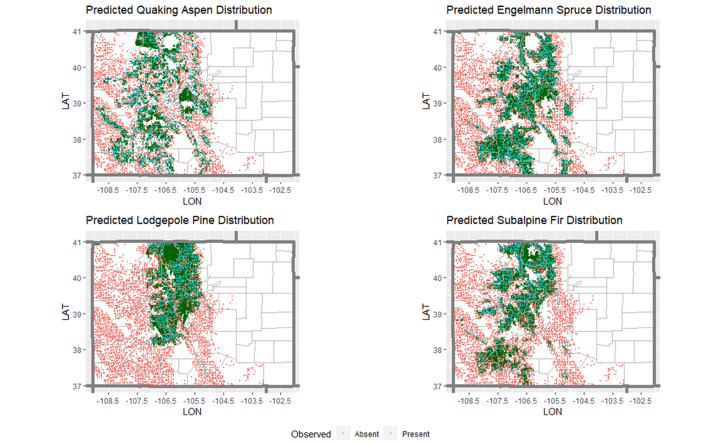

## Modeling distribution given a change in DIFS

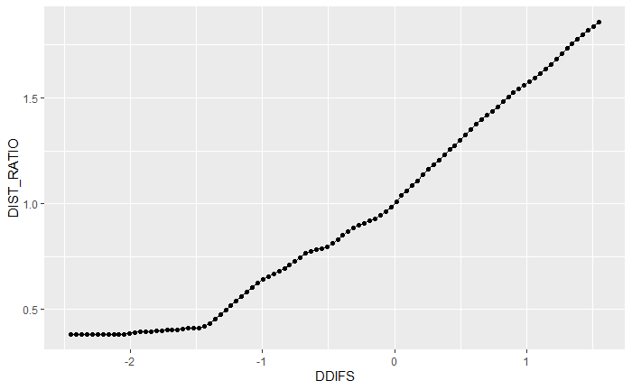

Calculate the actual temperature difference:

```
[1] 0.3178301
```

Distribution for 1-SD decrease in DIFS:

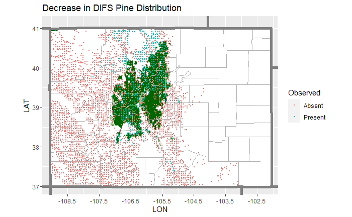

Distribution for 1-SD increase in DIFS:

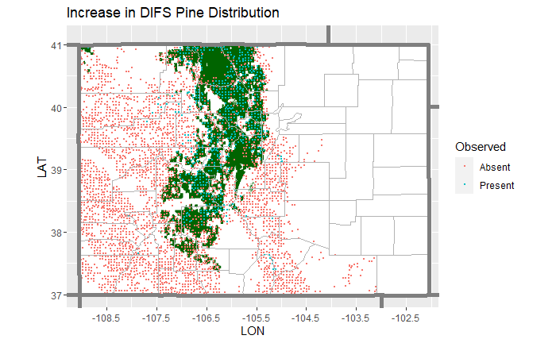

Final plot:

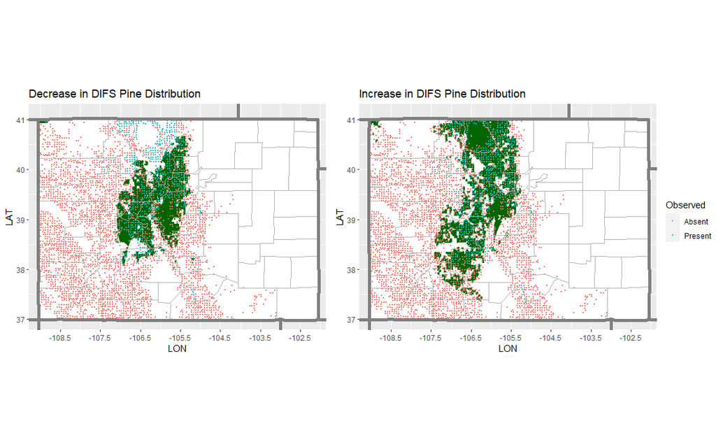

Let’s do something similar for fir by manipulating VARA:

Decrease in VARA:

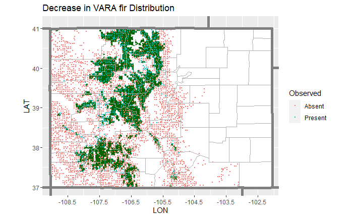

Increase in VAR for fir:

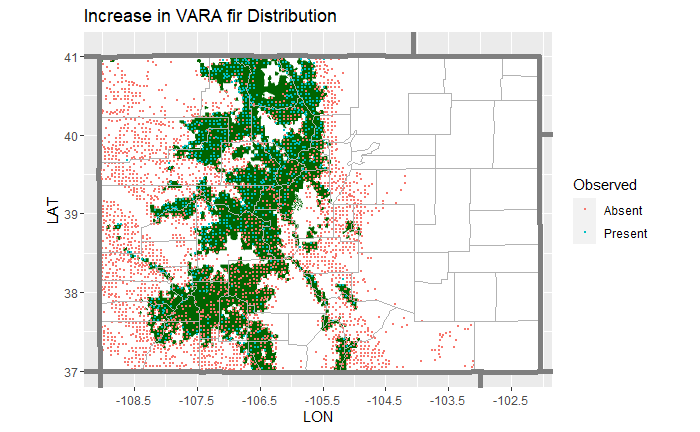

Final plot:

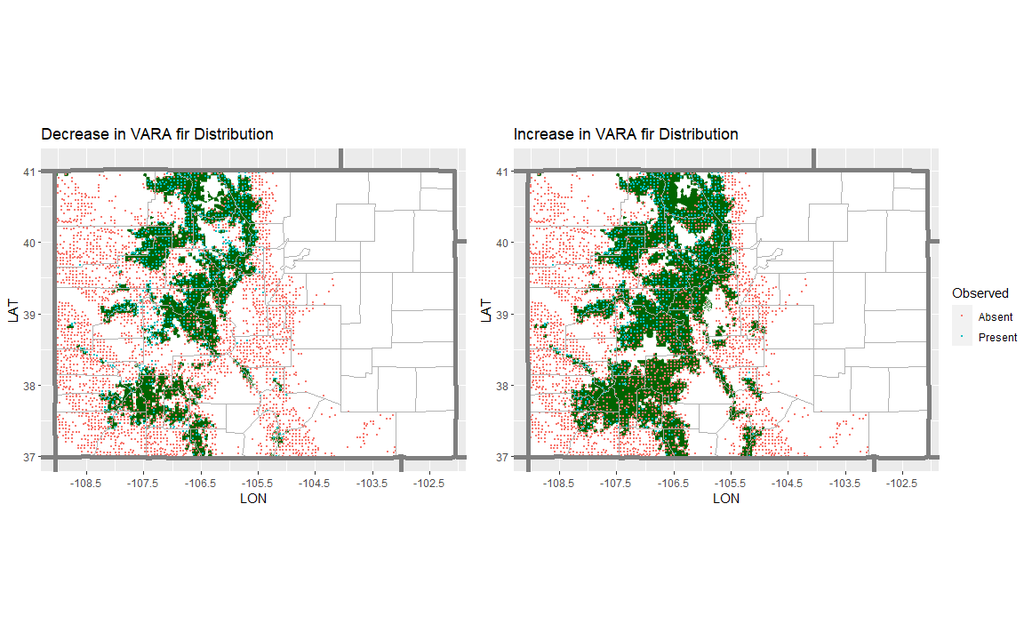

## Pine & Fir Abundance with a Tweedie Response

Create a new data-frame and XG matrices:

| n |
| --- |
| 0.1579023 |

Modify the cross-validation function for Tweedie regression:

## Pine Abundance

Model fitting and prediction accuracy:

```
[1] 153.0957
[1] 179.4623
```

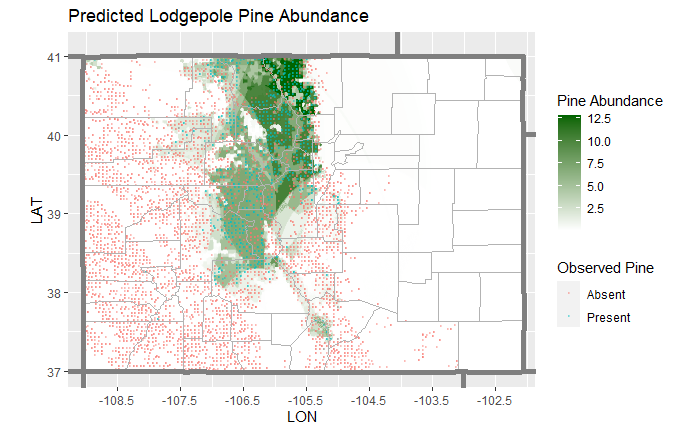

| Feature | Gain | Cover | Frequency |
| --- | --- | --- | --- |
| DIFS | 0.468452582 | 0.232033814 | 0.08695652 |
| ELEV | 0.219950944 | 0.287707357 | 0.18840580 |
| PPTS | 0.072658080 | 0.126612661 | 0.11594203 |
| DIFW | 0.057110757 | 0.103425173 | 0.07246377 |
| PPTW | 0.049407012 | 0.101259206 | 0.08695652 |
| VARW | 0.037747833 | 0.030201229 | 0.13043478 |
| VARS | 0.022399800 | 0.051389263 | 0.04347826 |
| VARP | 0.018276022 | 0.042154214 | 0.02898551 |
| JULT | 0.016654913 | 0.005162913 | 0.04347826 |
| FIELD_MOIST_SOIL_WT | 0.015460438 | 0.005387581 | 0.02898551 |

[output cut: 3 more lines]

## Fir Abundance

Model fitting and prediction accuracy:

```
[1] 36.71585
[1] 47.07591
```

Prediction and map:

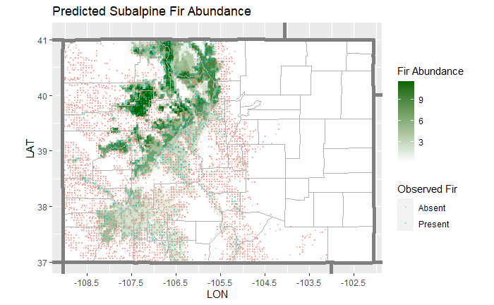

| Feature | Gain | Cover | Frequency |
| --- | --- | --- | --- |
| ELEV | 0.638355154 | 0.449181932 | 0.34426230 |
| VARA | 0.075037041 | 0.128587544 | 0.08196721 |
| AVGT | 0.073749966 | 0.033361472 | 0.08196721 |
| JANT | 0.065123207 | 0.094444214 | 0.09836066 |
| DIFW | 0.054157220 | 0.085574961 | 0.08196721 |
| VARW | 0.034434529 | 0.094541745 | 0.09836066 |
| PPTS | 0.024061031 | 0.039952633 | 0.06557377 |
| VARS | 0.016068151 | 0.030871760 | 0.06557377 |
| VARP | 0.004945901 | 0.025906947 | 0.01639344 |
| JULT | 0.004905937 | 0.009980321 | 0.01639344 |

[output cut: 3 more lines]

Final plot:

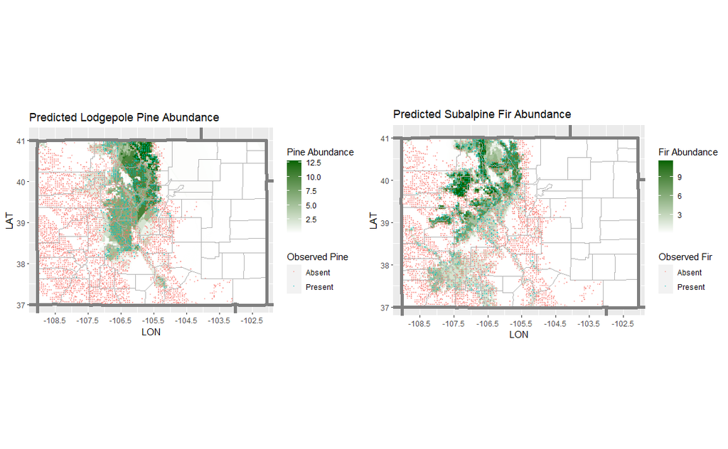